# Exploring 538 Data

Dan Tanner

February 24, 2017

```r
library(fivethirtyeight)
library(lmtest)
```

NAME: Dan Tanner UMICH ID: danjtan

# Test 1

```r
data("pulitzer")
```

## Question:

Do newspapers with more Pulitzer Prize finalists over the last two decades have larger distributions?

## Null Hypothesis:

There is no relationship between the number of Pulitzer Prize finalists in the past two decades and the distribution size of a newspaper.

## Test:

Linear Regression

## Plot:

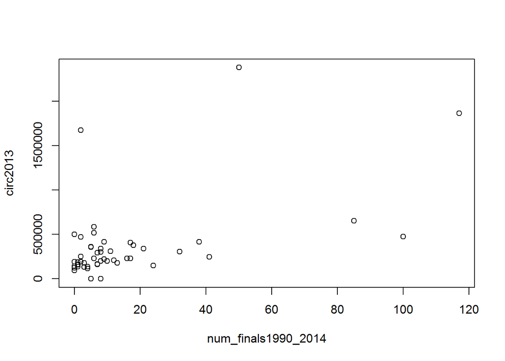

```r
plot(circ2013~num_finals1990_2014, data = pulitzer)
```

## Assumptions:

*Are the residuals normally distributed?*

```r
mod.pul <- lm(circ2013~num_finals1990_2014, data = pulitzer)
shapiro.test(residuals(mod.pul))
```

```
##
##  Shapiro-Wilk normality test
##
## data:  residuals(mod.pul)
## W = 0.65756, p-value = 1.544e-09
```

The residuals are NOT normally distributed. The test fails!

*Are the residuals autocorrelated?*

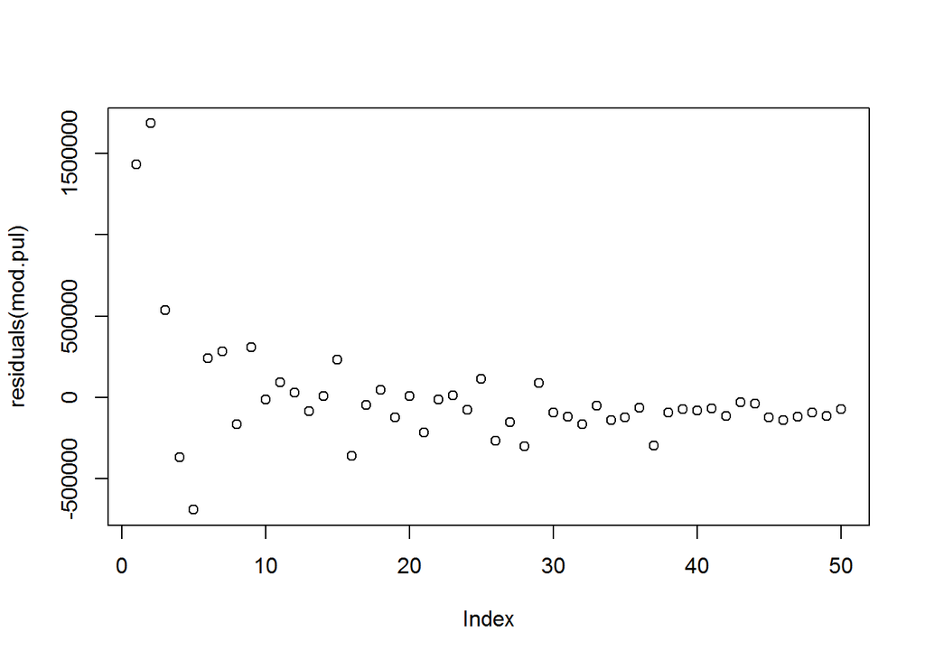

```r
plot(residuals(mod.pul))
```

It’s unclear if there’s any autocorrelation, but it looks like our residuals might not be homoscedastic.

```r
dwtest(mod.pul, alternative=c("two.sided"))
```

```
##
##  Durbin-Watson test
##
## data:  mod.pul
## DW = 0.72138, p-value = 1.501e-07
## alternative hypothesis: true autocorrelation is not 0
```

```r
bptest(mod.pul)
```

```
##
##  studentized Breusch-Pagan test
##
## data:  mod.pul
## BP = 3.2515, df = 1, p-value = 0.07136
```

We fail the autocorrelation test and just barely pass the test for homoscedasticity.

## Result:

```r
summary(mod.pul)
```

```
##
## Call:
## lm(formula = circ2013 ~ num_finals1990_2014, data = pulitzer)
##
## Residuals:
##     Min      1Q  Median      3Q     Max
## -691389 -124857  -75493   10701 1685765
##
## Coefficients:
##                     Estimate Std. Error t value Pr(>|t|)
## (Intercept)           219967      62757   3.505    0.001 **
## num_finals1990_2014     9462       2189   4.322 7.74e-05 ***
## ---
## Signif. codes:  0 '***' 0.001 '**' 0.01 '*' 0.05 '.' 0.1 ' ' 1
##
## Residual standard error: 377600 on 48 degrees of freedom
## Multiple R-squared:  0.2802, Adjusted R-squared:  0.2652
## F-statistic: 18.68 on 1 and 48 DF,  p-value: 7.744e-05
```

## Interpretation:

The assumptions of my test were not met, but if they were the results above would have been the findings. They would suggest that for every additional Pulitzer finalist a newspaper has, you could expect them to have an additional 9,462 readers (p = 7.74e-05).

# Test 2

```r
data("congress_age")
D_age <- congress_age[congress_age$party == "D","age"]
R_age <- congress_age[congress_age$party == "R","age"]
```

## Question:

Are Republican members of congress different in age when they start their sessions than Democrats?

## Null Hypothesis:

Republicans are not different in age from Democrats when they start their sessions.

## Test:

2-sample t-test

## Plot:

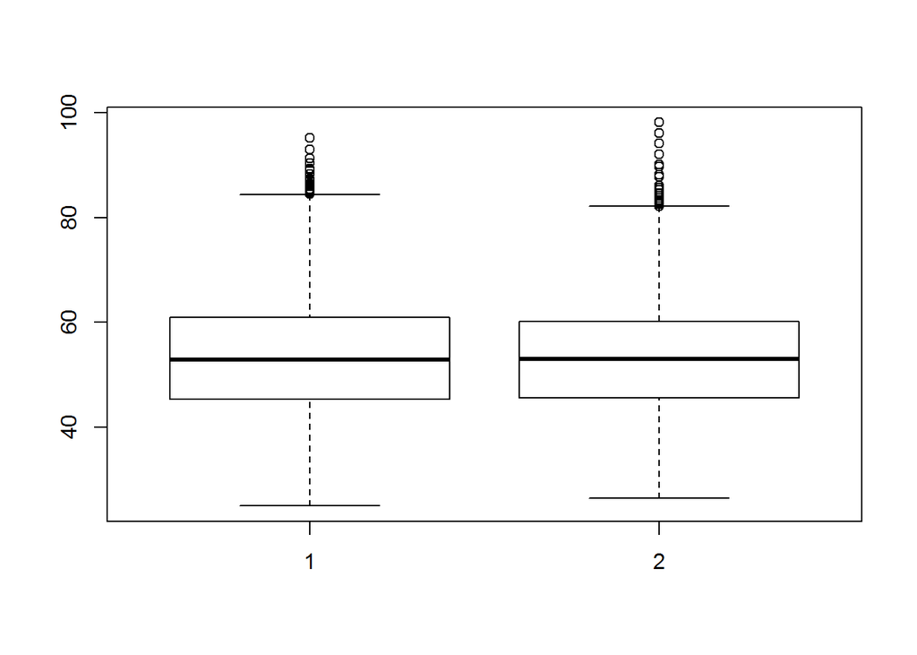

```r
boxplot(D_age, R_age)
```

## Assumptions:

Sample size is greater than 30, so we don’t have to check normality.

```r
var.test(D_age, R_age)
```

```
##
##  F test to compare two variances
##
## data:  D_age and R_age
## F = 1.137, num df = 10289, denom df = 8273, p-value = 8.676e-10
## alternative hypothesis: true ratio of variances is not equal to 1
## 95 percent confidence interval:
##  1.091377 1.184486
## sample estimates:
## ratio of variances
##           1.137031
```

Our samples don’t have equal variance!

## Result:

```r
t.test(D_age, R_age, var.equal=FALSE, paired=FALSE)
```

```
##
##  Welch Two Sample t-test
##
## data:  D_age and R_age
## t = 1.6884, df = 18130, p-value = 0.09136
## alternative hypothesis: true difference in means is not equal to 0
## 95 percent confidence interval:
##  -0.04255574  0.57140796
## sample estimates:
## mean of x mean of y
##  53.43147  53.16704
```

## Interpretation:

With p = ~0.09 we fail to reject the null hypothesis. Thus we conclude that Democrats and Republicans have had the similar ages at the beginning of their sessions.